# **MSDA Data Science Math Bridge**

## Final Project

### Logan Thomson

```r
library(hflights)
library(ggplot2)
library(MASS)
```

## **Probability**

Before caluculating on any fields, look at number of na (not available) values in each column:

```r
sapply(hflights, function(x) sum(is.na(x)))
```

```
##              Year             Month        DayofMonth         DayOfWeek
##                 0                 0                 0                 0
##           DepTime           ArrTime     UniqueCarrier         FlightNum
##              2905              3066                 0                 0
##           TailNum ActualElapsedTime           AirTime          ArrDelay
##                 0              3622              3622              3622
##          DepDelay            Origin              Dest          Distance
##              2905                 0                 0                 0
##            TaxiIn           TaxiOut         Cancelled  CancellationCode
##              3066              2947                 0                 0
##          Diverted
##                 0
```

### Define Random Variable X and Y

Both variables have the same amount of “not available” values; I did not want to replace them with zeros (or the mean of the actual values), as this would change the results.

```r
rand_var_x <- na.omit(hflights$ActualElapsedTime)
rand_var_y <- na.omit(hflights$AirTime)
```

Check for skew:

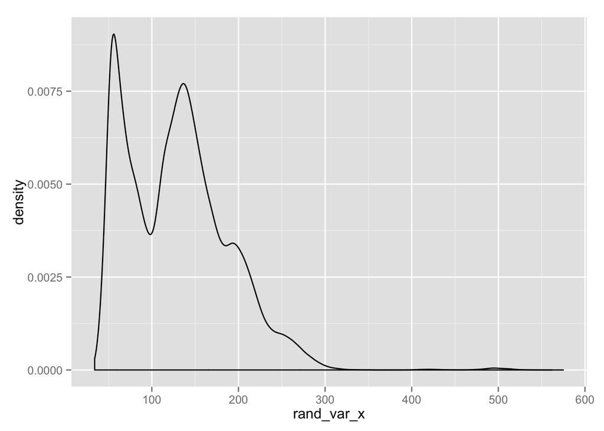

```r
qplot(rand_var_x, geom='density')
```

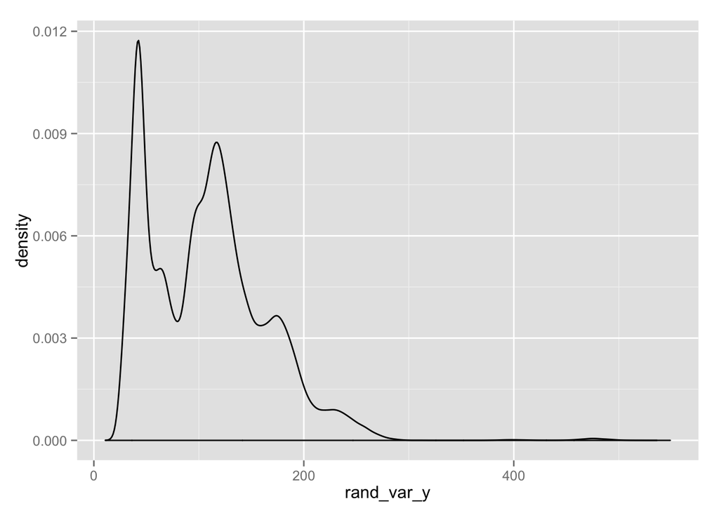

```r
qplot(rand_var_y, geom='density')
```

The mean is also larger than the median, so we know both variables are positively skewed

```r
# Summary stats of each variable
summary(rand_var_x)
```

```
##    Min. 1st Qu.  Median    Mean 3rd Qu.    Max.
##    34.0    77.0   128.0   129.3   165.0   575.0
```

```r
summary(rand_var_y)
```

```
##    Min. 1st Qu.  Median    Mean 3rd Qu.    Max.
##    11.0    58.0   107.0   108.1   141.0   549.0
```

```r
# Quartiles of each variable
quantile(rand_var_x)
```

```
##   0%  25%  50%  75% 100%
##   34   77  128  165  575
```

```r
quantile(rand_var_y)
```

```
##   0%  25%  50%  75% 100%
##   11   58  107  141  549
```

So, the third quartile for “Actual Elapsed Time” (x) of flights is 165, and the second quartile of “Air Time” (y) is 107.

### Table Values

```r
# <= x and <= y
R1C1 <- sum(rand_var_x <= 165 & rand_var_y <= 107)

# <= x and > y
R1C2 <- sum(rand_var_x <= 165 & rand_var_y > 107)

# Row 1 Total
R1C3 <- R1C1 + R1C2

# > x and <= y
R2C1 <- sum(rand_var_x > 165 & rand_var_y <= 107)

# > x and > y
R2C2 <- sum(rand_var_x > 165 & rand_var_y > 107)

# Row 2 Total
R2C3 <- R2C1 + R2C2

# Column Total Rows
R3C1 <- R1C1 + R2C1
R3C2 <- R1C2 + R2C2
R3C3 <- R3C1 + R3C2
```

### Create Table

```r
df_rows <- c("X <= x", "X > x", "Total")
df_cols <- c("Y <= y", "Y > y", "Total")

var_count_df <- data.frame(c(R1C1, R2C1, R3C1), c(R1C2, R2C2, R3C2), c(R1C3, R2C3, R3C3))

rownames(var_count_df) <- df_rows
colnames(var_count_df) <- df_cols
```

```r
var_count_df
```

```
##        Y <= y  Y > y  Total
## X <= x 112776  55403 168179
## X > x     140  55555  55695
## Total  112916 110958 223874
```

### Calculate Probabilities

1. P(X>x|Y>y)

```r
var_count_df[2,2] / var_count_df[3,2]
```

```
## [1] 0.5006849
```

2. P(X>x, Y>y)

```r
var_count_df[2,2] / var_count_df[3,3]
```

```
## [1] 0.248153
```

```r
var_count_df[1,2] / var_count_df[3,2]
```

```
## [1] 0.4993151
```

### Check for Independence

Setting the variables Only X > x:

```r
varA <- var_count_df[2,3]
```

All values of Y > y:

```r
varB <- var_count_df[3,2]
```

Calculate Probability

```r
ProbA <- varA / var_count_df[3,3]
ProbB <- varB / var_count_df[3,3]
ProbA * ProbB
```

```
## [1] 0.1233013
```

P(A|B) is .50068949, P(A) * P(B) is .1233013 If the variables were independent, then P(B) would have no effect on P(A|B). Therefore, (A|B) would be equal to P(A), so P(A and B) = P(A) * P(B). Since they are not equal, the variables are not independent.

### Chi-Square Test

I’m not too familiar with doing a Chi-squared test by hand, luckily R has a function to do the heavy-lifiting for me. The Chi-squared test is used to determine significant association between two variables.

```r
chisq.test(rand_var_x, rand_var_y)
```

```
##
##  Pearson's Chi-squared test
##
## data:  rand_var_x and rand_var_y
## X-squared = 14666000, df = 172300, p-value < 2.2e-16
```

Since the p-value is less than the significance level, then we have to reject the null hypothesis that the variables “Actual Elapsed Time” and “Air Time” are independent.

## Descriptive and Inferential Statistics

Univariate descriptive statistics explores each variable separately. Basic summary statistics are displayed above in the Probability section. In addition to those, here is a histogram for the general frequency distribution and the variance and standard deviation for each variable. I did not make a frequency table, as this would be very long, however the `table()` function can be used to create this.

### Univariate Descriptive Statistics and Plots

Variance and Standard Deviation of X

```r
# Variance
var(rand_var_x)
```

```
## [1] 3514.811
```

```r
# Std Dev
sd(rand_var_x)
```

```
## [1] 59.28584
```

Histogram of X with Bin size = 25

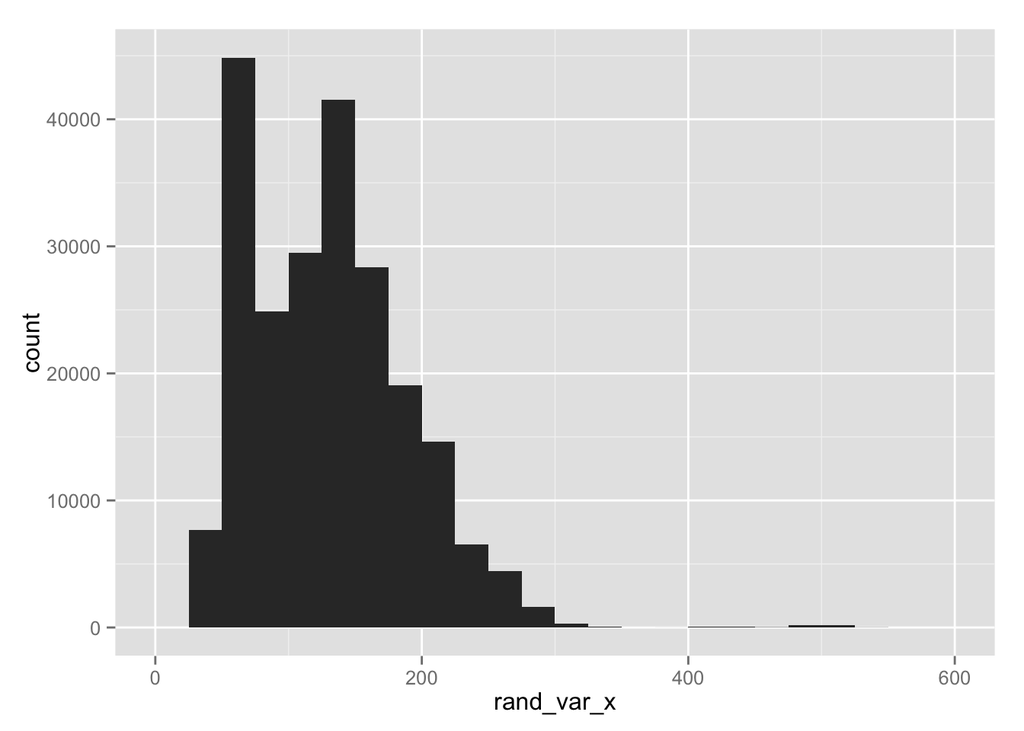

```r
qplot(rand_var_x, geom='histogram', binwidth=25)
```

Variance and Standard Deviation of Y

```r
# Variance
var(rand_var_y)
```

```
## [1] 3198.494
```

```r
# Std Dev
sd(rand_var_y)
```

```
## [1] 56.55523
```

Histogram of Y with Bin size = 25

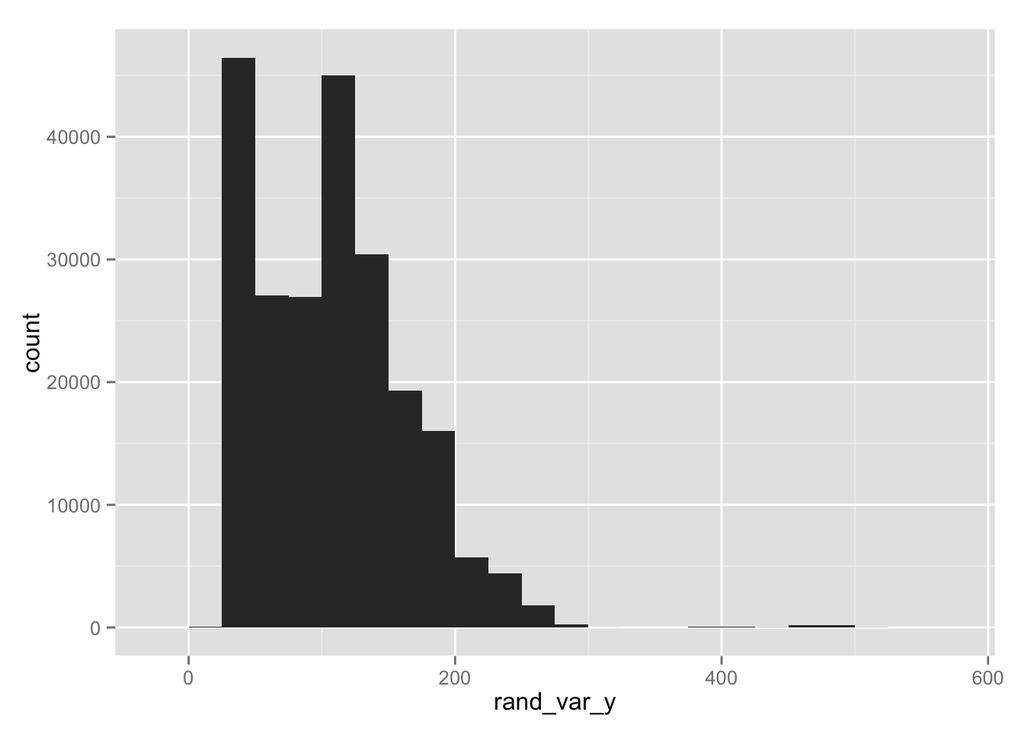

[figure not shown]

```r
qplot(rand_var_y, geom='histogram', binwidth=25)
```

### 95% Confidence Interval for Difference in Mean

I knew how to get the 95% confidence interval for a sample mean, but wasn’t sure about the difference in mean. A simple internet search turned up the `t.test` function in R.

```r
t.test(rand_var_x, rand_var_y, conf.level = .95)
```

```
##
##  Welch Two Sample t-test
##
## data:  rand_var_x and rand_var_y
## t = 122.32, df = 446750, p-value < 2.2e-16
## alternative hypothesis: true difference in means is not equal to 0
## 95 percent confidence interval:
##  20.84201 21.52081
## sample estimates:
## mean of x mean of y
##  129.3237  108.1423
```

The lower limit of the 95% confidence interval is 20.84, and the upper limit of the 95% confidence interval is 21.52.

### Correlation Matrix

I could test the correlation between my two variables by simply putting them into the `cor` function in R.

```r
cor(rand_var_x, rand_var_y)
```

```
## [1] 0.9889335
```

However, I needed to produce a correlation matrix. Conveneintly, `cor()` will take a matrix or data frame, so I will simply create a data frame of my two variables, and enter that into the `cor` function:

```r
xy_matrix <- data.frame(rand_var_x, rand_var_y)
head(xy_matrix)
```

```
##   rand_var_x rand_var_y
## 1         60         40
## 2         60         45
## 3         70         48
## 4         70         39
## 5         62         44
## 6         64         45
```

```r
# Now enter it into the cor() fucntion
cor_matrix <- cor(xy_matrix)
```

Again, R has a function to calculate the confidence level between two variables. `cor.test` returns the confidence interval (at 95% by default), as well as the correlation value given above

```r
cor.test(rand_var_x, rand_var_y, conf.level=.99)
```

```
##
##  Pearson's product-moment correlation
##
## data:  rand_var_x and rand_var_y
## t = 3153.9, df = 223870, p-value < 2.2e-16
## alternative hypothesis: true correlation is not equal to 0
## 99 percent confidence interval:
##  0.9888131 0.9890527
## sample estimates:
##       cor
## 0.9889335
```

The lower limit of the 99% confidence interval is .9888, and the upper limit is .9890. Therefore, we can be fairly certain that the true population correlation lies between the two limits.

## **Linear Algebra and Correlation**

### Create the Precision Matrix

We create the precision matrix by inverting our correlation matrix that was made using the `cor` function above. Rather than calculating this by hand (1/ad-bc), We can use the `solve()` function to easily invert the matrix.

```r
prec_matrix <- solve(cor_matrix)
prec_matrix
```

```
##            rand_var_x rand_var_y
## rand_var_x   45.43292  -44.93014
## rand_var_y  -44.93014   45.43292
```

To multiply the matrices, we can simply use `%*%` in R

```r
# Precision matrix by correlation matrix
zapsmall(prec_matrix %*% cor_matrix)
```

```
##            rand_var_x rand_var_y
## rand_var_x          1          0
## rand_var_y          0          1
```

```r
# Correlation matrix by precision matrix
zapsmall(cor_matrix %*% prec_matrix)
```

```
##            rand_var_x rand_var_y
## rand_var_x          1          0
## rand_var_y          0          1
```

## **Calculus-based Probability & Statistics**

### Shifting variable so minimum is above zero.

Both of the variables I selected have their minimum values above zero, so I did not shift the distribution of either. The `MASS` package has already been loaded, so we can use the `fitdistr` function on either variable.

```r
fitdistr(rand_var_x, densfun='exponential')
```

```
##        rate
##   7.732532e-03
##  (1.634255e-05)
```

I was not sure how to find the optimal value of lambda - so I am unable to go further.